# Data Science and Data Analytics

## Two categorical variables

We can create variations of this plot by changing the `position` argument of `geom_bar`. The default is `stack`. Most useful for comparing distributions are relative frequency plots achieved with `position = "fill"`:

- Code
- Plot

```r
ggplot(species_freq, aes(x = island, y = Freq, fill = species)) +
  geom_bar(stat = "identity", position = "fill")
```

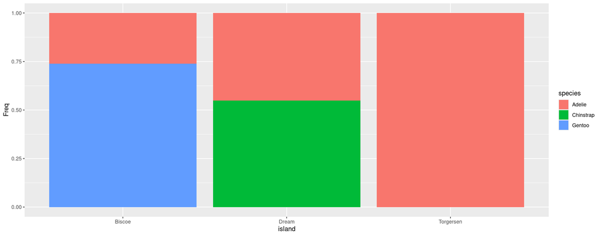

## Two numerical variables

In the introductory example, we have already seen **scatter plots** and **smooth curves** as ways to illustrate the relationship between two numerical variables. Scatter plots are an absolute staple in a data scientist’s toolbox:

- Code
- Plot

```r
ggplot(penguins, aes(x = flipper_length_mm, y = body_mass_g)) +
  geom_point()
```

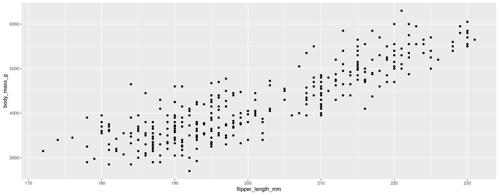

## Three or more variables

The introductory example displayed three variables: `flipper_length_mm` (`x`), `body_mass_g` (`y`) and `species` (`color` and `shape`). In general, we have the following options to introduce additional variables into a scatter plot:

- Use additional **aesthetics**:
  - Colour $\to$ `color` (categorical or numerical variables)
  - Shape $\to$ `shape` (categorical)
  - Size $\to$ `size` (categorical or numerical variables)
  - Transparency $\to$ `alpha` (categorical or numerical variables)
- Split plot into **facets**, subplots that each display one subset of the data (categorical variables).
- Animate the plot (categorical or numerical variables, especially time).
- Create a 3D scatter plot (categorical or numerical variables).

## Three or more variables

- When using aesthetics to represent additional variables, we must be aware that different sorts of variables can be represented more or less well by different kinds of visual representations.
- While there are no one-size-fits-all recipes, consider the following order as a heuristic when introducing additional variables into a 2D scatter plot:
  - For **continuous variables**: size, colour, transparency.
  - For **categorical variables**: colour, shape.
- For example, in our scatter plot of penguin flipper lengths vs. body masses, we might want to introduce categorical information on **species** and **island**. By the heuristic, we use colour for the first and shape for the second.

## Three or more variables – Colour and shape

In the default setting, the points are quite small, which makes it hard to distinguish the shapes. To mitigate this, we additionally set the `size` aesthetic to something larger, namely 3.

- Code
- Plot

```r
ggplot(penguins, aes(x = flipper_length_mm, y = body_mass_g,
                     color = species, shape = island)) +
  geom_point(size = 3)
```

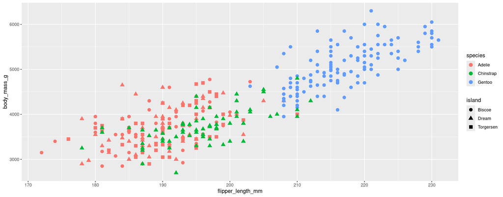

## Three or more variables – Colour and size

Let’s say we wanted a scatter plot of penguin bill length vs. bill depth for different species. Additionally, we want information on body mass included as well. A logical choice to represent the latter would be `size`:

- Code
- Plot

```r
ggplot(penguins, aes(x = bill_length_mm, y = bill_depth_mm,
                     color = species, size = body_mass_g)) +
  geom_point()
```

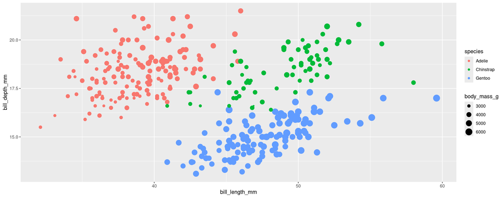

## Three or more variables – Multiple aesthetics

If we now really wanted to go mad, we could add the island back in via the `shape` aesthetic and additionally include the flipper length via the `alpha` aesthetic, so that longer flippers are represented by more opaque points:

- Code
- Plot

```r
ggplot(penguins, aes(x = bill_length_mm, y = bill_depth_mm,
                     color = species, size = body_mass_g,
                     shape = island, alpha = flipper_length_mm)) +
  geom_point()
```

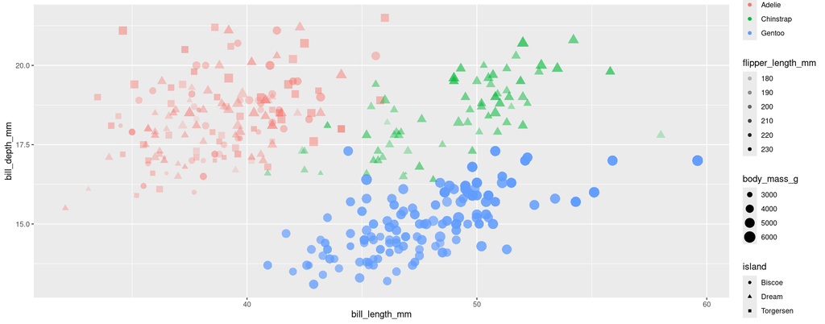

## Three or more variables – Faceting

- Clearly, there is now **too much information** in this plot.
- Adding too many aesthetic mappings to a plot makes it **cluttered** and difficult to make sense of.
- Another way to introduce additional categorical variables is to split your plot into several **facets**.
- A facet is a **subplot** that displays one subset of the data. For example, there could be one facet for each factor level of a categorical variable.
- We can use facets to explore **conditional relationships**, like the relationship between flipper length and body weight on each of the three islands.

## Three or more variables – Faceting

To facet a plot by a single variable, we use `facet_wrap`. It takes a so-called **formula** as its first argument, which we create with `~` followed by the name of a categorical variable.

- Code
- Plot

```r
ggplot(penguins, aes(x = flipper_length_mm, y = body_mass_g,
                     color = species)) +
  geom_point() +
  facet_wrap(~island)
```

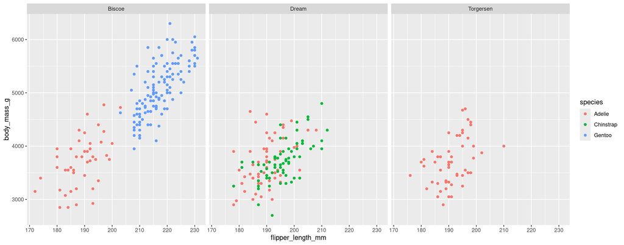

## Three or more variables – Faceting

To facet a plot by two variables, we use `facet_grid`. We specify the variable to be faceted in the **rows** before the `~` and the variable to be faceted in the **columns** after it. For example, we could additionally facet `sex` in the rows:

- Code
- Plot

```r
ggplot(penguins, aes(x = flipper_length_mm, y = body_mass_g,
                     color = species)) +
  geom_point() +
  facet_grid(sex~island)
```

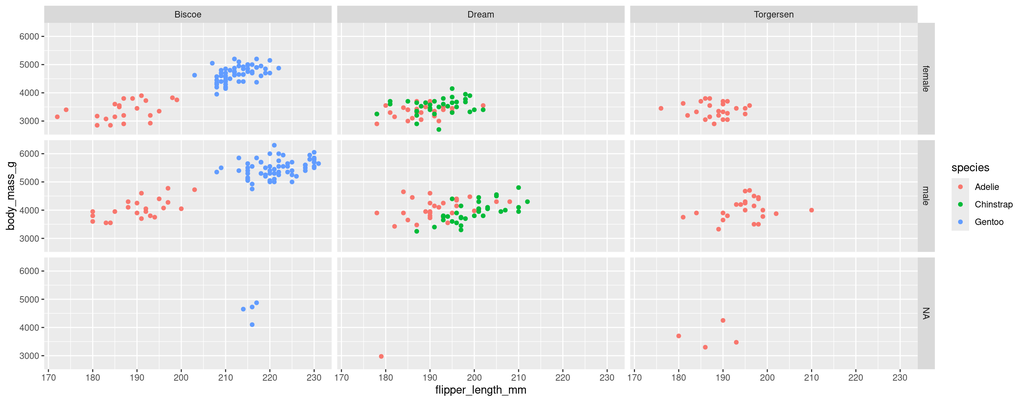

## Three or more variables – Labels

- For some data sets, we can also display an additional variable in a scatter plot by creating informative **labels** for the points.
- Our penguin data set is not a good example to illustrate this, so we consider the `elections_historic` data set from the `socviz` package instead:

  ```r
  library(socviz)
  elections_historic <- as.data.frame(elections_historic)
  head(elections_historic[, c("year", "winner", "win_party", "ec_pct",
                              "popular_pct", "winner_label")])
  ```

  ```
    year                 winner win_party ec_pct popular_pct  winner_label
  1 1824      John Quincy Adams     D.-R. 0.3218      0.3092    Adams 1824
  2 1828         Andrew Jackson      Dem. 0.6820      0.5593  Jackson 1828
  3 1832         Andrew Jackson      Dem. 0.7657      0.5474  Jackson 1832
  4 1836       Martin Van Buren      Dem. 0.5782      0.5079    Buren 1836
  5 1840 William Henry Harrison      Whig 0.7959      0.5287 Harrison 1840
  6 1844             James Polk      Dem. 0.6182      0.4954     Polk 1844
  ```

- This data set contains information on US presidential elections from 1824 to 2016. We will have a look at the winner’s share of the electoral college vote and the popular vote.

## Three or more variables – Labels

In a scatter plot, we want to have the popular vote share on the `x` axis and the electoral college vote share on the `y` axis. If we only map these two aesthetics, the plot looks quite uninformative…

- Code
- Plot

```r
ggplot(elections_historic, aes(x = popular_pct, y = ec_pct)) +
  geom_point()
```

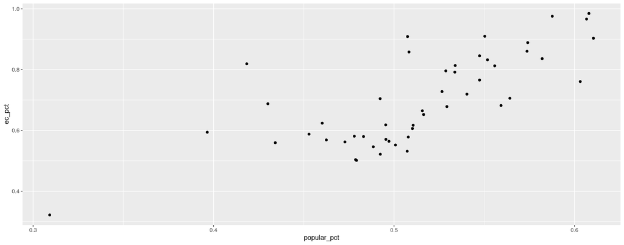

## Three or more variables – Labels

We do not know who any of these points represent. This is a perfect use case for **labeling** the points. For this, we can use the `label` aesthetic together with the `text` **geom** (there is also a `label` geom, which would work as well):

- Code
- Plot

```r
ggplot(elections_historic, aes(x = popular_pct, y = ec_pct, label = winner_label)) +
  geom_text() +
  geom_point()
```

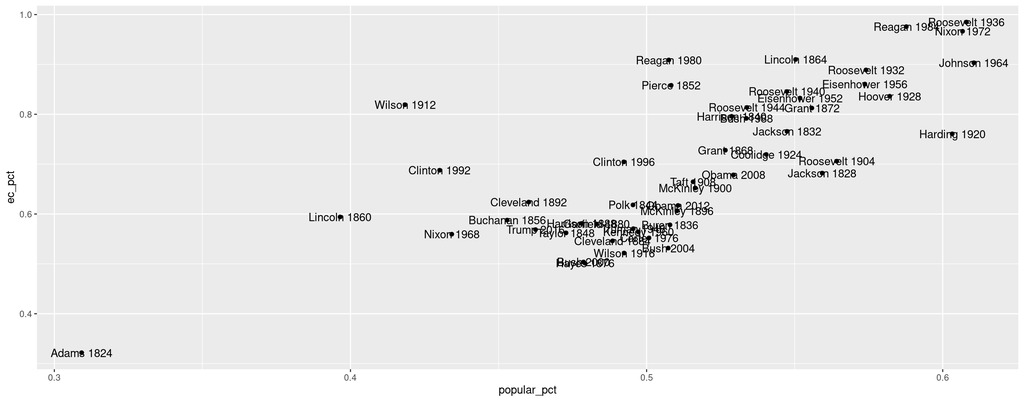

## Three or more variables – Labels

That is much better already. However, now, there is a lot of overlap. To remedy this, we need an additional library called `ggrepel`, which provides us with a `text_repel` **geom** to avoid overlapping labels:

- Code
- Plot

```r
library(ggrepel)
ggplot(elections_historic, aes(x = popular_pct, y = ec_pct, label = winner_label)) +
  geom_text_repel() +
  geom_point()
```

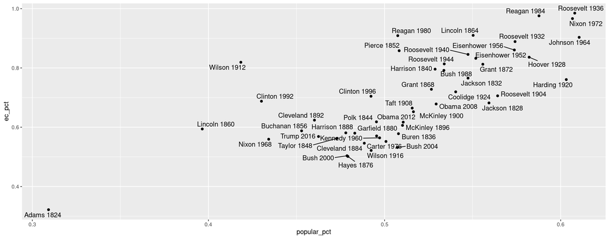

## Customizing our plots

- So far, we have seen how to create and extend basic plots, like bar plots, density plots, histograms, and scatter plots by tailoring aesthetic mappings and layering on suitable **geoms** according to our needs.
- However, the customization usually does not stop there. We might want to …
  - … add informative titles, subtitles, captions and axis labels to the plot.
  - … use colours and shapes different from the ones `ggplot` uses by default.
  - … adapt the scale of the `x` and / or `y` axis.
  - … change the font type and size for labels and titles.
  - … set the whole plot in a different theme to suit corporate guidelines.
  - … and so much more…
- In `ggplot2`, virtually every aspect of a plot is **customizable**. We will only have a look at how to customize some of the most important ones.

# Getting the details right – Scales, guides and themes

## Understanding scales, guides and themes

- Outside of aesthetic mappings and geoms, there are three types of functions that do most of the heavy lifting when it comes to customizing our plot:
  - The family of `scale_` functions
  - The `guides` function and
  - The `theme` function.
- Due to the sheer amount of options for customizability and the partial overlap between some of these functions, things can become confusing very quickly when working through these functions.
- Let’s start with a basic delineation of scales, guides and themes.

## Understanding scales, guides and themes

- A rough guide on the use of these functions is the following:
  - **Scales**: every aesthetic mapping has a scale. If we want to adjust how that scale is marked or graduated, we use a `scale_` function.
  - **Guides**: Many scales come with a legend to help us interpret the graph. These are called guides and can be adjusted with the help of the `guides` function.
  - **Themes**: graphs have other features not strictly connected to the structure of the data being displayed. These include background colour, font size, legend placement, etc. To adjust these, we use the `theme` function.
- We will now dig deeper into each of these three domains of customization and see examples of how the corresponding functions are used to change the appearance of the data displayed.

## Understanding scales

Let’s come back to an earlier example from the penguin data set:

- Code
- Plot

```r
ggplot(penguins, aes(x = flipper_length_mm, y = body_mass_g,
                     color = species, shape = island)) +
  geom_point(size = 3)
```

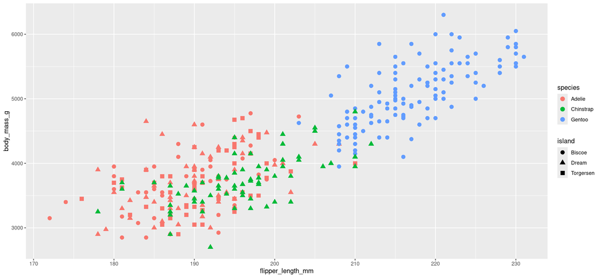

## Understanding scales

This plot has four aesthetic mappings:

- The variable `flipper_length_mm` is mapped to `x`.
- The variable `body_mass_g` is mapped to `y`.
- The variable `species` is mapped to `color`.
- The variable `island` is mapped to `shape`.

And each of these mappings has a **scale**:

- `flipper_length_mm` is a **continuous** variable, so the `x` scale is continuous.
- `body_mass_g` is a **continuous** variable, so the `y` scale is continuous.
- `species` is an unordered **categorical** variable, so the `color` scale is discrete.
- `island` is an unordered **categorical** variable, so the `shape` scale is discrete.

## Understanding scales

- Scales for these mappings may have labels, axis tick marks at particular positions, or specific colours or shapes. If we want to adjust them, we use one of the `scale_` functions.
- These functions have the following general structure:

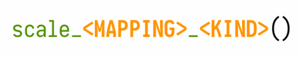

- So, for example:
  - `scale_x_continuous` controls `x` scales for continuous variables
  - `scale_y_continuous` controls `y` scales for continuous variables
  - `scale_color_discrete` controls `color` scales for discrete variables
  - `scale_shape_discrete` controls `shape` scales for discrete variables

## Scales in action

Let’s see this in action. Say we wanted to override the default for tick marks by having a mark every 5 mm on the `x` axis and every 500 g on the `y` axis. We can use the `breaks` argument to control the position of the tick marks:

- Code
- Plot

```r
ggplot(penguins, aes(x = flipper_length_mm, y = body_mass_g,
                     color = species, shape = island)) +
  geom_point(size = 3) +
  scale_x_continuous(breaks = seq(170, 230, by = 5)) +
  scale_y_continuous(breaks = seq(3000, 6000, by = 500))
```

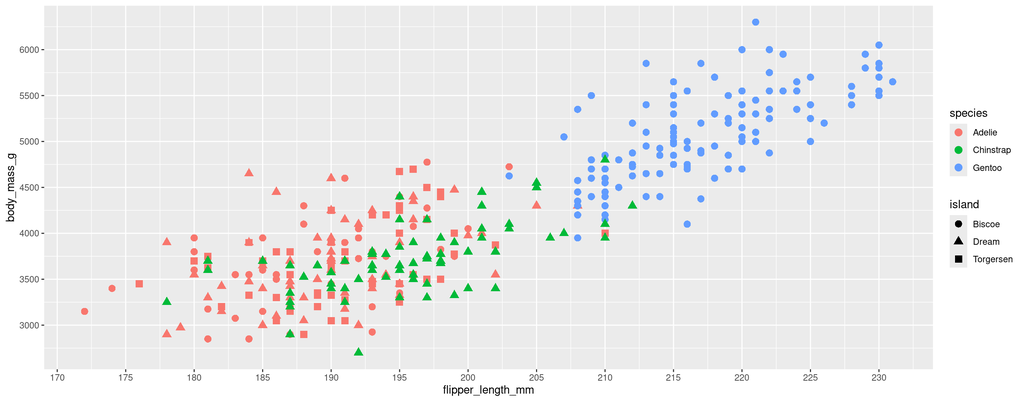

## Scales in action

Now, let’s say we also wanted to change the colours and shapes used to represent species and island, respectively. For **manually** adapting them, we use `scale_color_manual` and `scale_shape_manual`:

- Code
- Plot

```r
ggplot(penguins, aes(x = flipper_length_mm, y = body_mass_g,
                     color = species, shape = island)) +
  geom_point(size = 3) +
  scale_x_continuous(breaks = seq(170, 230, by = 5)) +
  scale_y_continuous(breaks = seq(3000, 6000, by = 500)) +
  scale_color_manual(values = c("red", "blue", "green")) +
  scale_shape_manual(values = c(17, 18, 8))
```

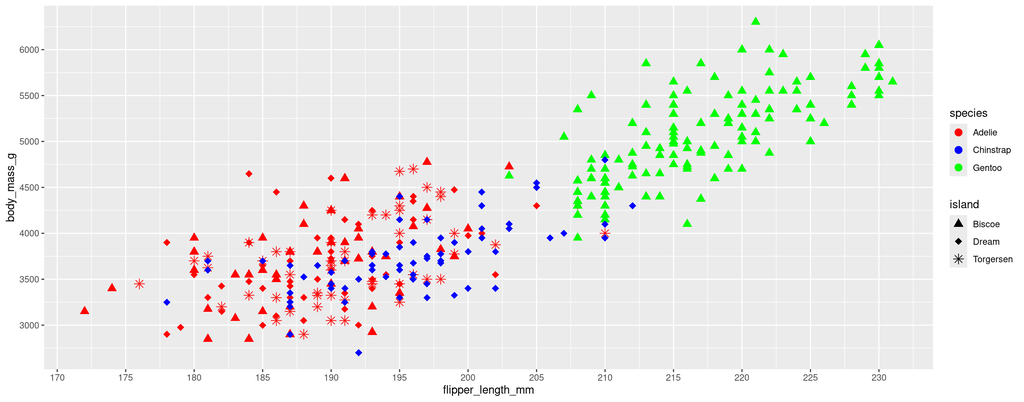

## A word on shapes

- The following shapes are most commonly used in R:

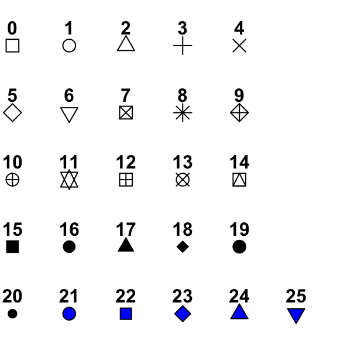

- You can reference them by using the numbers indicated and passing them to `scale_shape_manual` in the order of the factor levels.
- In the example before, we had `Biscoe = 17`, `Dream = 18` and `Torgersen = 8`.

## A word on colour

- Whenever we map `color` or `fill` as an aesthetic, `ggplot2` uses default colour or fill scales that do a fine enough job for exploratory data analysis, but typically have to be tweaked for publication-ready plots.
- In the example before, we have **manually** overridden the default using `scale_color_manual` and the names of three colours (red, blue and green).
- Choosing the right colour(s) for data visualization is actually a very complex problem that has to consider adequate representation of the underlying data as well as differences in colour perception.
- We will only briefly skim the surface of colour choice by looking into some of the excellent options for setting colours that already exist out of the box in `ggplot2`.

## A word on colour

- A collection of colours used for representing data is called a **palette**.
- A very popular family of such palettes available in `ggplot2` are the `colorbrewer` palettes. For **discrete** variables, they come in three different types:
  - **Qualitative**: best suited to represent unordered categorical data, e.g. penguin species.
  - **Sequential**: best suited to represent ordered data that progresses from low to high, e.g. school grades or counts.
  - **Diverging**: best suited to represent ordered data with a neutral midpoint and extremes diverging in both directions, e.g. Likert scales.
- Depending on the type of data we want represented, we can choose a palette from the corresponding family.

## A word on colour – Qualitative palettes

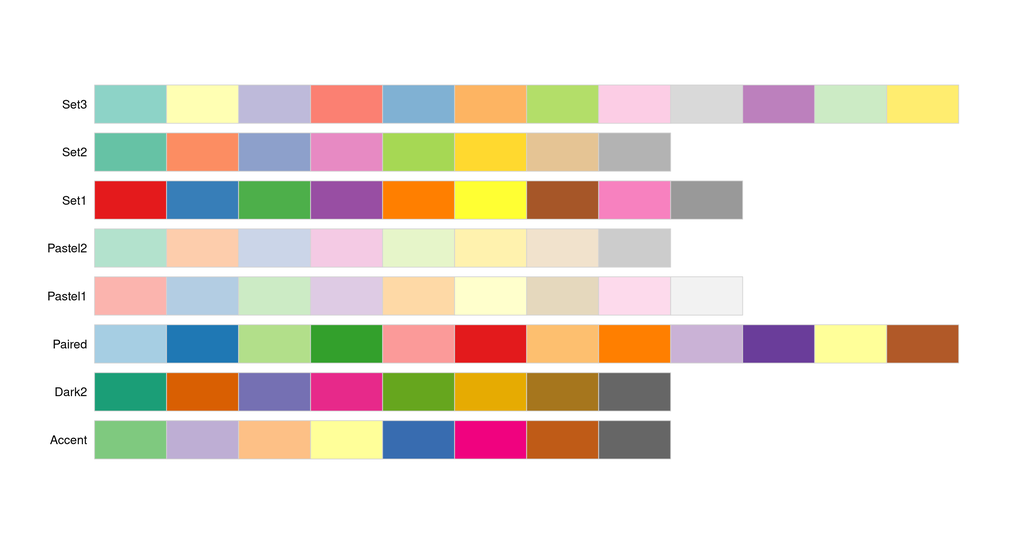

## A word on colour – Sequential palettes

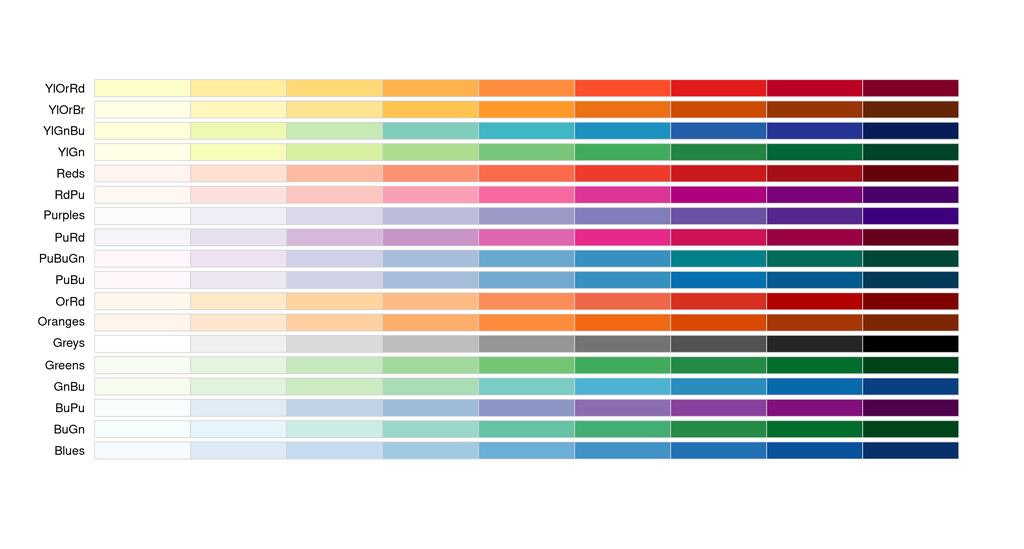

## A word on colour – Diverging palettes

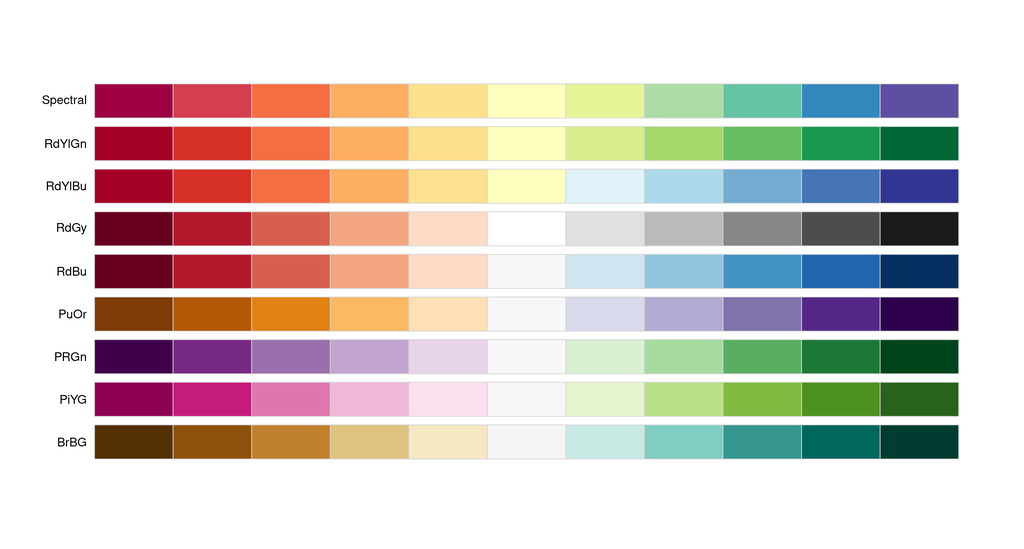

## A word on colour – How to use colorbrewer

- We can access all of these palettes in our plots by referencing them using the names given in the functions `scale_color_brewer` and `scale_fill_brewer`, respectively.
- In our example, we have the `species` variable mapped to colour, which is an unordered categorical variable. A suitable palette to represent it might therefore be `Dark2`, for example.
- To do this, we would run the following code (result on the next slide):

  ```r
  ggplot(penguins, aes(x = flipper_length_mm, y = body_mass_g,
                       color = species, shape = island)) +
    geom_point(size = 3) +
    scale_x_continuous(breaks = seq(170, 230, by = 5)) +
    scale_y_continuous(breaks = seq(3000, 6000, by = 500)) +
    scale_color_brewer(palette = "Dark2")
  ```

## A word on colour – How to use colorbrewer

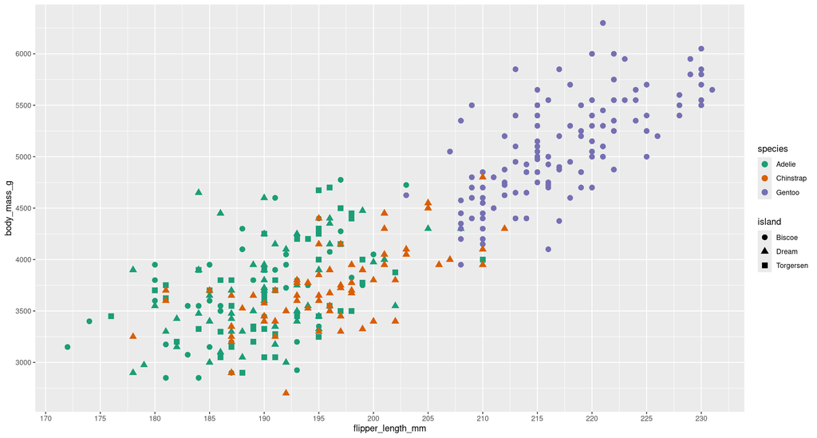

## A word on colour – How to use colorbrewer

- With these `colorbrewer` palettes, we can represent data from **discrete** variables, like categorical or count data.
- However, what if we want to represent a **continuous** variable using colour, such as penguin bill length?
- All **sequential** and **diverging** `colorbrewer` palettes can also be used for continuous scales. Depending on the aesthetic, we only have to pass them into the functions `scale_color_distiller` or `scale_fill_distiller`.
- Penguin bill length does not have a neutral midpoint, so we use a sequential palette like `YlOrRd` to represent it (result on the next slide):

  ```r
  ggplot(penguins, aes(x = flipper_length_mm, y = body_mass_g,
                       color = bill_length_mm)) +
    geom_point(size = 3) +
    scale_x_continuous(breaks = seq(170, 230, by = 5)) +
    scale_y_continuous(breaks = seq(3000, 6000, by = 500)) +
    scale_color_distiller(palette = "YlOrRd")
  ```

## A word on colour – How to use colorbrewer

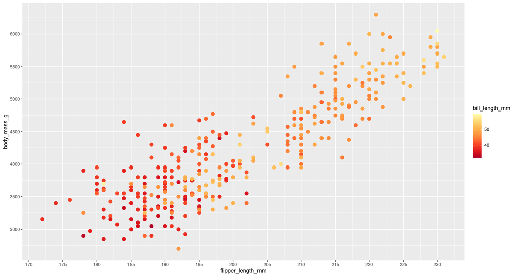

## A final word on colour

- The options for colour choice are virtually endless. The goal here was merely to introduce colour scales and how to change them.
- If you find yourself unhappy with the colour palettes provided by `colorbrewer`, have a look at the [Palette Finder](https://r-graph-gallery.com/color-palette-finder) in the R Graph Gallery:

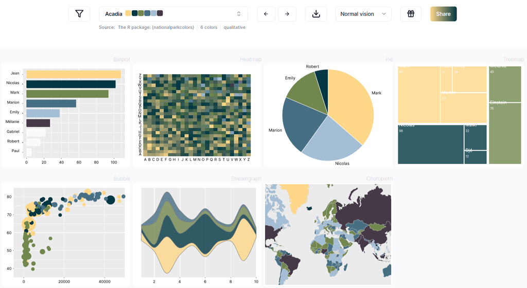

## Understanding guides

Now let’s discuss **guides**. For this, consider again our violin plot from earlier:

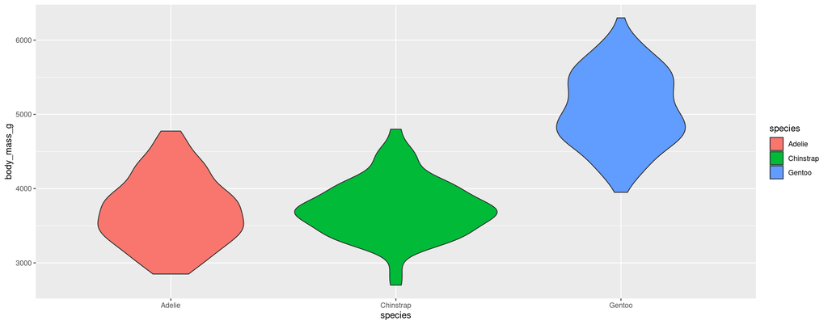

This plot contains redundant information: the species can be inferred from the axis labels, we do not need the additional legend for `species`.

## Understanding guides

To “switch off” the guide for a particular aesthetic, we can simply call the `guides` function with the name of the aesthetic as a named argument set to `"none"`:

- Code
- Plot

```r
ggplot(penguins, aes(x = species, y = body_mass_g, fill = species)) +
  geom_violin() +
  guides(fill = "none")
```

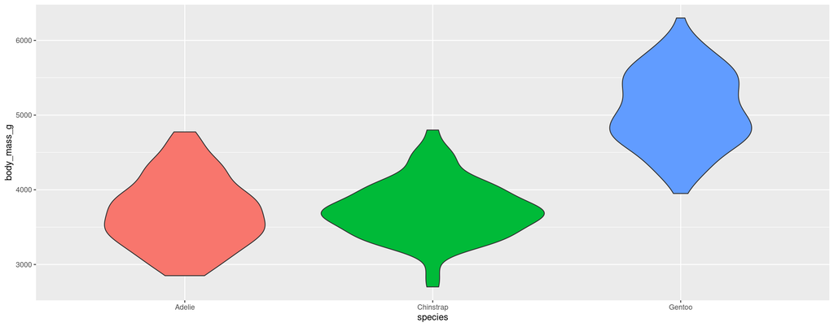

## Understanding guides

- Of course, the `guides` function can do much more than simply to “switch off” legends for individual scales.
- In fact, it can be used to customize virtually every aspect of a legend such as:
  - where the title of the legend should go
  - where the labels should be placed
  - in which orders the labels should be displayed
  - and much more…
- As with many aspects of `ggplot2`, this bridge is best crossed, when you first come to it…

## Understanding themes

- Finally, a very important domain of plot customization is opened up by the `theme` function. It allows us to customize all aspects that are not directly related to the data being displayed.
- A very common basic use of the `theme` function is to place the legend at a different location in the plot and to change font sizes of different labels (result on the next slide):

  ```r
  ggplot(penguins, aes(x = flipper_length_mm, y = body_mass_g,
                       color = species, shape = island)) +
    geom_point(size = 3) +
    labs(title = "Body mass and flipper length",
         subtitle = "Dimensions for Adelie, Chinstrap, and Gentoo Penguins",
         caption = "Source: palmerpenguins package",
         color = "Species",
         shape = "Island") +
    theme(legend.position = "bottom",
          plot.title = element_text(size = rel(1.75)),
          plot.subtitle = element_text(size = rel(1.5)),
          plot.caption = element_text(size = rel(0.75)))
  ```

## Understanding themes

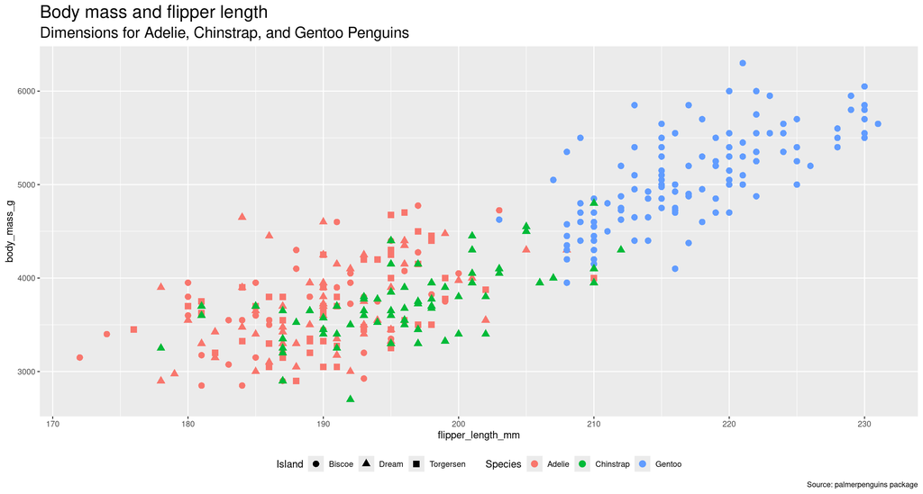

## Using pre-built themes

- While customizing every single aspect of a plot is definitely possible in `ggplot2`, it is also incredibly cumbersome and usually not necessary.
- Instead, we can simply layer on a pre-built **theme** that changes the overall look of a plot all at once.
- **Themes** that come shipped with `ggplot2` are: `bw`, `classic`, `dark`, `gray` (default), `light`, `linedraw`, `minimal`, `test` and `void`.
- The following slide gives an overview of our plot would look like in each of these themes. If none of those suit your needs, you can have a look at the `ggthemes` package that has plenty more to [offer](https://yutannihilation.github.io/allYourFigureAreBelongToUs/ggthemes/).

## Using pre-built themes

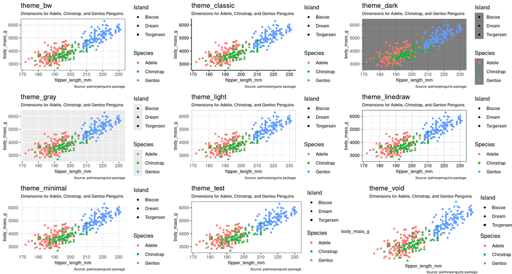

## Saving your work

- Now that we know how to create and customize our own plots, we might want to **save** them to include them in a presentation or send them to a colleague.
- The easiest way to do this is to use the function `ggsave`. By default, it will save the most recently created plot into the file name you provide:

  ```r
  ggsave(filename = "my_figure.png")
  ```

- You can save the plot as PDF, JPG, PNG (or several other formats) by changing the **file ending** accordingly.
- You can also change the dimensions and the resolution of the plot by changing arguments `width`, `height` and `dpi`, respectively.
- As always, for more details, refer to the documentation via `?ggsave`.

# A sneak peek into what is possible

## A sneak peek into what is possible

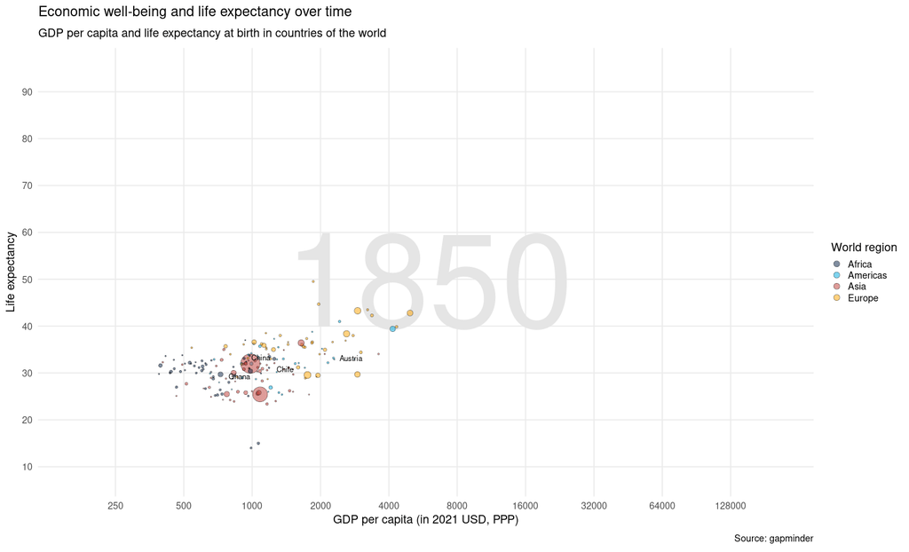